# Homework 3: Databases, web scraping, and a basic Shiny app

Max Cheatle

2023-05-30

# 1 Money in UK politics

## 1.1 Open a connection to the database

The database made available by Simon Willison is an `SQLite` database

```r
sky_westminster <- DBI::dbConnect(
  drv = RSQLite::SQLite(),
  dbname = here::here("data", "sky-westminster-files.db")
)
```

How many tables does the database have?

```r
DBI::dbListTables(sky_westminster)
```

```
## [1] "appg_donations"  "appgs"           "member_appgs"    "members"
## [5] "parties"         "party_donations" "payments"
```

## 1.2 Which MP has received the most amount of money?

```r
# First I am setting up the tables as database objects, so that I can manipulate them as dataframes

payments_db <- dplyr::tbl(sky_westminster, "payments")
members_db <- dplyr::tbl(sky_westminster, "members")

# Checking outputs.... looks good

#view(payments_db)
#view(members_db)

# We could jump straight to a join here, but I'll summarise on payments first to keep it easier to follow

id_payments <- payments_db %>%

  # Grouping by member_id for summation
  group_by(member_id) %>%

  # Summing the value of all payments to each member_id
  summarise(total_recieved = sum(value))

# Now I want to join to the members table, where payments_db$member_id = members_db$id

member_payments <- left_join(id_payments, members_db, by = c("member_id" = "id"))

# Now let's take that table to see who's getting the most cash

member_payments %>%
  select(member_id, name, total_recieved) %>%
  arrange(desc(total_recieved))
```

```
## # Source:     SQL [?? x 3]
## # Database:   sqlite 3.39.2 [/Users/maxcheatle/Library/CloudStorage/OneDrive-LondonBusinessSchool/Electives/E628 Data Science/dsb2023_mcheatle/data/sky-westminster-files.db]
## # Ordered by: desc(total_recieved)
##    member_id name             total_recieved
##    <chr>     <chr>                     <dbl>
##  1 m8        Theresa May            2809765.
##  2 m1508     Sir Geoffrey Cox       2191387.
##  3 m1423     Boris Johnson          1282402
##  4 m4514     Keir Starmer            799936.
##  5 m1211     Andrew Mitchell         769373.
##  6 m3958     Fiona Bruce             712321.
##  7 m14       John Redwood            692438.
##  8 m4483     Rishi Sunak             546043
##  9 m4097     Liz Truss               538678.
## 10 m188      Ed Davey                441681.
## # ℹ more rows
```

- Looks like Theresa May is a favorite for donors!

## 1.3 Any `entity` that accounts for more than 5% of all donations?

```r
# Let's find out which entity is splashing big cash

# First let me find the total amount of donations in our payments_db dataframe

total_donos <- payments_db %>%
  summarise(total_donos = sum(value)) %>%
  pull(total_donos)

# Then do the same, but on an entity-by-entity basis

entity_donos <- payments_db %>%
  group_by(entity) %>%
  summarise(entity_donos = sum(value))

# Finally, a simple caluclation to work out the percentages

entity_donos %>%
  mutate(pct_donos = entity_donos/total_donos*100) %>%
  arrange(desc(pct_donos))
```

```
## # Source:     SQL [?? x 3]
## # Database:   sqlite 3.39.2 [/Users/maxcheatle/Library/CloudStorage/OneDrive-LondonBusinessSchool/Electives/E628 Data Science/dsb2023_mcheatle/data/sky-westminster-files.db]
## # Ordered by: desc(pct_donos)
##    entity                                entity_donos pct_donos
##    <chr>                                        <dbl>     <dbl>
##  1 Withers LLP                               1812732.     5.25
##  2 Fiona Bruce and Co LLP                     711749.     2.06
##  3 Charles Stanley                            674821.     1.95
##  4 Unite                                      636313.     1.84
##  5 Cambridge Speaker Series                   408200      1.18
##  6 GMB Union                                  397738.     1.15
##  7 MPM Connect                                345217      1.00
##  8 Centerview Partners LLP                    277724.     0.805
##  9 Council of Insurance Agents & Brokers      276130      0.800
## 10 Hindustan Times                            261652.     0.758
## # ℹ more rows
```

- Withers LLP’s donations account for 5.3% of total donations!

## 1.4 Do `entity` donors give to a single party or not?

```r
# First let's get a list of the distinct entities and count them

# Saving the value for use later
total_entities <- payments_db %>%
  distinct(entity) %>%
  summarise(entities = n()) %>%
  pull(entities)

total_entities
```

```
## [1] 2213
```

```r
# Now let's find out who only donates to one party

entity_parties <- payments_db %>%

  # Joining payments and members, since members has party_id which we need
  left_join(members_db, by = c("member_id" = "id")) %>%
  select(entity, party_id) %>%
  arrange(desc(entity)) %>%

  # Now selecting the distinct entity and party_id rows
  distinct(entity, party_id) %>%

  # Grouping by entity for incoming calculation
  group_by(entity) %>%

  # Counting the number of parties that each entity donates to
  summarise(parties_dono = n()) %>%

  # Converting the number of parties donated to, to a categorical single/multiple variable
   mutate(parties_dono = case_when(
    parties_dono > 1 ~ "Multiple",
    TRUE ~ "Single"
  )) %>%

  # Grouping by our new categorical variable
  group_by(parties_dono) %>%

  # And counting the respective instances of single/multiple donors
  summarise(count = n())

 # Now presenting the answers

entity_parties %>%

  # Creating a pct column, using the total_entities saved from the start of this chunk
  mutate(pct_multiple = as.numeric(count)/total_entities*100)
```

```
## # Source:     SQL [2 x 3]
## # Database:   sqlite 3.39.2 [/Users/maxcheatle/Library/CloudStorage/OneDrive-LondonBusinessSchool/Electives/E628 Data Science/dsb2023_mcheatle/data/sky-westminster-files.db]
## # Ordered by: desc(entity)
##   parties_dono count pct_multiple
##   <chr>        <int>        <dbl>
## 1 Multiple       177         8.00
## 2 Single        2036        92.0
```

- There are 2213 distinct donor entities, of which only 8% (177) donate to multiple parties

## 1.5 Which party has raised the greatest amount of money in each of the years 2020-2022?

```r
# knitr::include_graphics(here::here("images", "total_donations_table.png"), error = FALSE)

# First creating tables as databse objects

parties_db <- dplyr::tbl(sky_westminster, "parties")

# Now gathering the necessary data

yearly_payments <-

  payments_db %>%

    # Opted to use sql() here, as I'm fluent in SQL and couldn't find a reliable way to do this using dplyr. I found a working method, but it then causes issues with the upcoming joins
    mutate(year = as.integer(sql("SUBSTR(date, -4)"))) %>%
    filter(year >= 2020) %>%

    # We now need the join with the members table where the party_id is stored
    left_join(members_db, by = c("member_id" = "id")) %>%

    # Again, just reducing to the necessary cols
    select(year, member_id, value, party_id) %>%

    # Left joining to parties_db, which has the party names
    left_join(parties_db, by = c("party_id" = "id")) %>%

    # Grouping by year and party name for sum
    group_by(year, name) %>%
    summarise(total_year_donatations = sum(value)) %>%

    # Now ungrouping to find total per year and calculate percentage
    ungroup(name) %>%
    mutate(prop = total_year_donatations / sum(total_year_donatations) * 100)

yearly_payments
```

```
## # Source:   SQL [?? x 4]
## # Database: sqlite 3.39.2 [/Users/maxcheatle/Library/CloudStorage/OneDrive-LondonBusinessSchool/Electives/E628 Data Science/dsb2023_mcheatle/data/sky-westminster-files.db]
## # Groups:   year
##     year name                      total_year_donatations    prop
##    <int> <chr>                                      <dbl>   <dbl>
##  1  2020 Alba Party                                 1320   0.0125
##  2  2020 Conservative                            6035344. 57.1
##  3  2020 Democratic Unionist Party                  5715.  0.0540
##  4  2020 Green Party                                9500   0.0898
##  5  2020 Independent                              230103.  2.18
##  6  2020 Labour                                  3615844. 34.2
##  7  2020 Liberal Democrats                        537694   5.08
##  8  2020 Plaid Cymru                               23072   0.218
##  9  2020 Scottish National Party                  108599.  1.03
## 10  2020 Sinn Féin                                  1911   0.0181
## # ℹ more rows
```

```r
# My numbers here are different, but I really can't understand why. I also noticed that some parties don't appear every year in the screenshot attached - perhaps this is where I'm going wrong. I've also iteratively consulted ChatGPT and it seems not be getting any different numbers.
```

… and then, based on this data, plot the following graph.

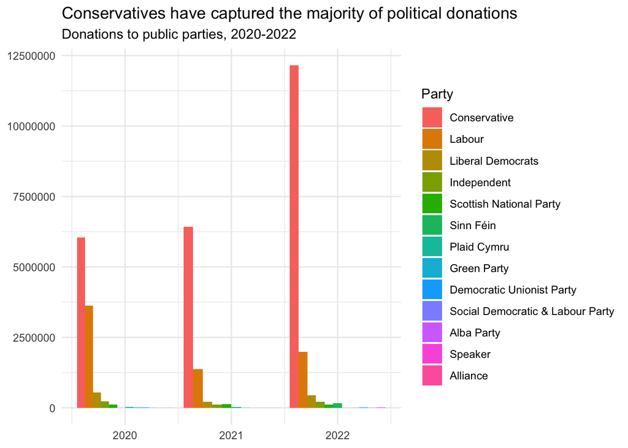

```r
# knitr::include_graphics(here::here("images", "total_donations_graph.png"), error = FALSE)

yearly_payments %>%

    # Now plotting, making sure to reorder our fill
    ggplot(aes(y = total_year_donatations, x = year, fill = fct_reorder(name, -total_year_donatations))) +

    # position = "dodge" to prevent stacking
    geom_bar(stat = "identity", position = "dodge") +

    # Aesthetics
    theme_minimal() +
    labs(title = "Conservatives have captured the majority of political donations", subtitle = "Donations to public parties, 2020-2022", x = NULL, y = NULL, fill = "Party")
```

This uses the default ggplot colour pallete, as I dont want you to worry about using the [official colours for each party](https://en.wikipedia.org/wiki/Wikipedia:Index_of_United_Kingdom_political_parties_meta_attributes). However, I would like you to ensure the parties are sorted according to total donations and not alphabetically. You may even want to remove some of the smaller parties that hardly register on the graph. Would facetting help you?

Finally, when you are done working with the databse, make sure you close the connection, or disconnect from the database.

```r
dbDisconnect(sky_westminster)
```

# 2 Anonymised Covid patient data from the CDC

## 2.1 Obtain the data

```
## 0.09 sec elapsed
```

```
## FileSystemDataset with 1 Parquet file
## 97,799,772 rows x 19 columns
## $ case_month                     <string> "2021-09", "2022-09", "2022-01", "2020…
## $ res_state                      <string> "TX", "TX", "TX", "CA", "IL", "CA", "N…
## $ state_fips_code                 <int32> 48, 48, 48, 6, 17, 6, 36, 36, 36, 53, …
## $ res_county                     <string> "TARRANT", NA, "HARRIS", "SAN BERNARDI…
## $ county_fips_code                <int32> 48439, NA, 48201, 6071, 17031, 6085, 3…
## $ age_group                      <string> "18 to 49 years", "18 to 49 years", "1…
## $ sex                            <string> "Male", "Male", "Female", "Female", "F…
## $ race                           <string> "White", "White", "Unknown", "Asian", …
## $ ethnicity                      <string> "Non-Hispanic/Latino", "Non-Hispanic/L…
## $ case_positive_specimen_interval <int32> NA, NA, NA, NA, 0, NA, 0, 0, 0, 0, 0, …
## $ case_onset_interval             <int32> NA, NA, -1, NA, 0, NA, NA, NA, NA, 0, …
## $ process                        <string> "Missing", "Missing", "Missing", "Miss…
## $ exposure_yn                    <string> "Missing", "Missing", "Missing", "Miss…
## $ current_status                 <string> "Laboratory-confirmed case", "Probable…
## $ symptom_status                 <string> "Missing", "Missing", "Symptomatic", "…
## $ hosp_yn                        <string> "Missing", "Missing", "No", "No", "No"…
## $ icu_yn                         <string> "Missing", "Missing", "Missing", "Miss…
## $ death_yn                       <string> "Missing", "Missing", "Missing", "Miss…
## $ underlying_conditions_yn       <string> NA, NA, NA, NA, NA, NA, NA, NA, NA, NA…
```

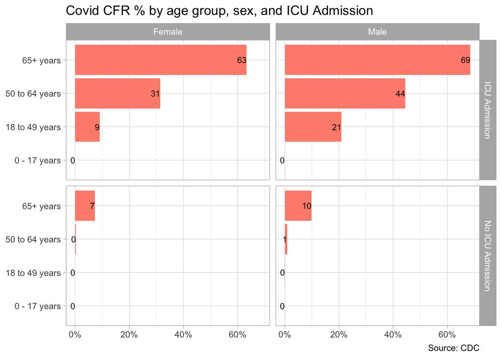

```r
# knitr::include_graphics(here::here("images", "covid-CFR-ICU.png"), error = FALSE)

# Let's give it a go by creating the necessary data frame first

cdc_data %>%

  # Making sure we only count certain ICU admissions/non-admissions
  filter(icu_yn %in% c("Yes", "No")) %>%

  # Making sure we only count certain deaths/non-deaths
  filter(death_yn %in% c("Yes", "No")) %>%

  # Making sure we only count certain males/females
  filter(sex == "Male" | sex == "Female") %>%

  # Removing rows without age_group variable
  filter(age_group != "Missing") %>%

  # Renaming for clarity
  mutate(icu_yn = case_when(
    icu_yn == "Yes" ~ "ICU Admission",
    TRUE ~ "No ICU Admission"
  )) %>%

  # Wanted to change death_yn column to a binary numerical value, so I can use sum() in the summarise without needing to filter
  mutate(death_yn = case_when(
    death_yn == "Yes" ~ "1", # Note here that 1 = Death
    TRUE ~ "0"
  )) %>%

  # Grouping by the categories given in the example plot
  group_by(age_group, sex, icu_yn) %>%

  # Calculating our inputs
  summarise(total_deaths = sum(as.numeric(death_yn)), total_cases = n()) %>%

  # Calculating our variable of interest
  mutate(cfr = total_deaths/total_cases) %>%

  # Collecting as data frame
  collect() %>%

  # And plotting
  ggplot(aes(x = cfr, y = age_group)) +
  geom_col(fill = "#ff8e7c") +

  # Faceting in grid format
  facet_grid(rows = vars(icu_yn), cols = vars(sex)) +

  # Now aesthetics
  geom_text(aes(label = round(cfr*100, 0), hjust = 1), size = 3) +
  labs(title = "Covid CFR % by age group, sex, and ICU Admission", caption = "Source: CDC", x = NULL, y = NULL) +
  theme_light() +
  scale_x_continuous(labels = percent_format())
```

The previous plot is an aggregate plot for all three years of data. What if we wanted to plot Case Fatality Ratio (CFR) over time? Write code that collects the relevant data from the database and plots the following

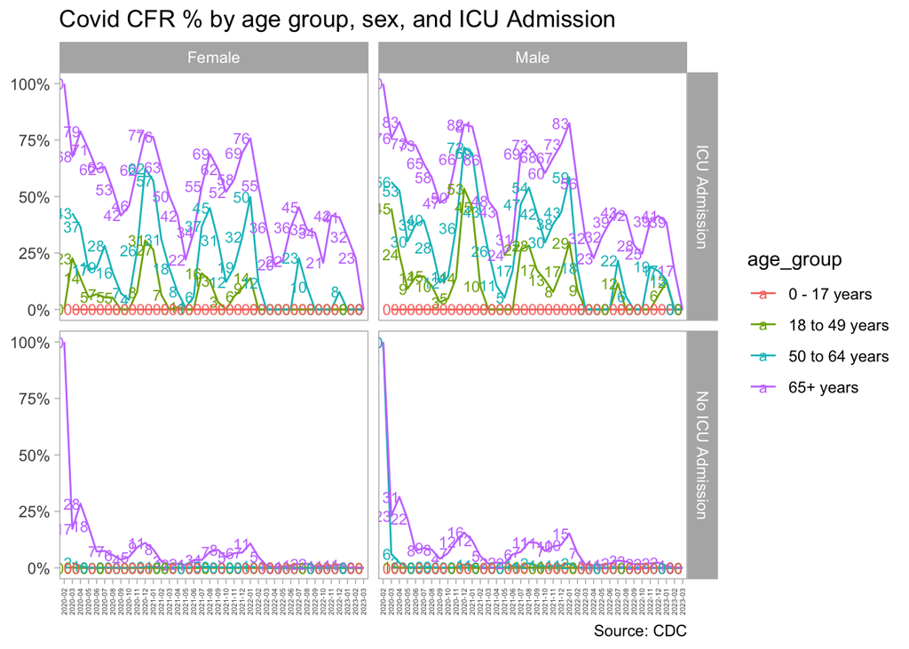

```r
# knitr::include_graphics(here::here("images", "cfr-icu-overtime.png"), error = FALSE)

cdc_data %>%

  # Making sure we only count certain ICU admissions/non-admissions
  filter(icu_yn %in% c("Yes", "No")) %>%

  # Making sure we only count certain deaths/non-deaths
  filter(death_yn %in% c("Yes", "No")) %>%

  # Making sure we only count certain males/females
  filter(sex == "Male" | sex == "Female") %>%

  # Removing rows without age_group variable
  filter(age_group != "Missing") %>%

  # Renaming for clarity
  mutate(icu_yn = case_when(
    icu_yn == "Yes" ~ "ICU Admission",
    TRUE ~ "No ICU Admission"
  )) %>%

  # Wanted to change death_yn column to a binary numerical value, so I can use sum() in the summarise without needing to filter
  mutate(death_yn = case_when(
    death_yn == "Yes" ~ "1", # Note here that 1 = Death
    TRUE ~ "0"
  )) %>%

  # Grouping by the categories given in the example plot
  group_by(case_month, age_group, sex, icu_yn) %>%

  # Calculating our inputs
  summarise(total_deaths = sum(as.numeric(death_yn)), total_cases = n()) %>%

  # Calculating our variable of interest
  mutate(cfr = total_deaths/total_cases) %>%

  # Collecting as data frame
  collect() %>%

    # And plotting
  ggplot(aes(x = case_month, y = cfr)) +
  geom_line(aes(group = age_group, color = age_group)) +

  # Faceting in grid format
  facet_grid(rows = vars(icu_yn), cols = vars(sex)) +

  # Now aesthetics
  geom_text(aes(label = round(cfr*100, 0), hjust = 1, color = age_group), size = 3) +
  labs(title = "Covid CFR % by age group, sex, and ICU Admission", caption = "Source: CDC", x = NULL, y = NULL) +
  theme_light() +
  scale_y_continuous(labels = percent_format()) +
  theme(panel.grid = element_blank(),
        axis.text.x = element_text(angle = 90, vjust = 0.5, hjust = 1, size = 4))  +
  NULL
```

```r
urban_rural <- read_xlsx(here::here("data", "NCHSURCodes2013.xlsx")) %>%
  janitor::clean_names()
```

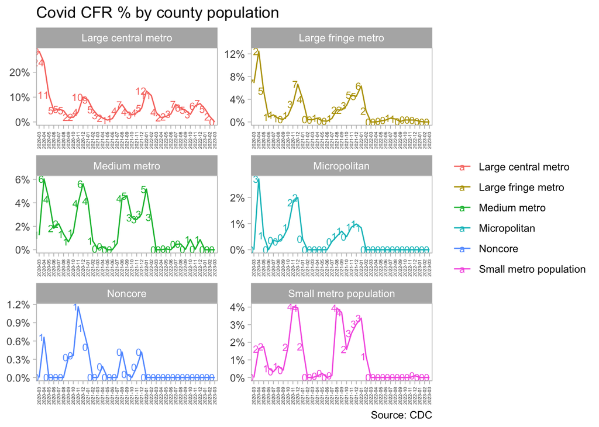

```r
# knitr::include_graphics(here::here("images", "cfr-county-population.png"), error = FALSE)

cdc_data %>%

  # Making sure we only count certain ICU admissions/non-admissions
  filter(icu_yn %in% c("Yes", "No")) %>%

  # Making sure we only count certain deaths/non-deaths
  filter(death_yn %in% c("Yes", "No")) %>%

  # Making sure we only count certain males/females
  filter(sex == "Male" | sex == "Female") %>%

  # Removing rows without age_group variable
  filter(age_group != "Missing") %>%

  # Renaming for clarity
  mutate(icu_yn = case_when(
    icu_yn == "Yes" ~ "ICU Admission",
    TRUE ~ "No ICU Admission"
  )) %>%

  # Wanted to change death_yn column to a binary numerical value, so I can use sum() in the summarise without needing to filter
  mutate(death_yn = case_when(
    death_yn == "Yes" ~ "1", # Note here that 1 = Death
    TRUE ~ "0"
  )) %>%

  # Now let's join the urban_rural table
  mutate(county_fips_code = as.double(county_fips_code)) %>%
  left_join(urban_rural, by = c("county_fips_code" = "fips_code")) %>%


  # Grouping by the categories given in the example plot
  group_by(case_month, x2013_code) %>%

  # Calculating our inputs
  summarise(total_deaths = sum(as.numeric(death_yn)), total_cases = n()) %>%

  # Calculating our variable of interest
  mutate(cfr = total_deaths/total_cases) %>%

  # Collecting as data frame
  collect() %>%

  # Let's remove NAs
  filter(x2013_code != "NA") %>%
  filter(case_month != "2020-02") %>%

  # And rename x2013_code names
  mutate(x2013_code = case_when(
    x2013_code == 1 ~ "Large central metro",
    x2013_code == 2 ~ "Large fringe metro",
    x2013_code == 3 ~ "Medium metro",
    x2013_code == 4 ~ "Small metro population",
    x2013_code == 5 ~ "Micropolitan",
    x2013_code == 6 ~ "Noncore"
  )) %>%

  # And plotting
  ggplot(aes(x = case_month, y = cfr)) +
  geom_line(aes(group = x2013_code, color = x2013_code)) +

  # Faceting in grid format
  facet_wrap(~ x2013_code, nrow = 3, scales = "free") +

  # Now aesthetics
  geom_text(aes(label = round(cfr*100, 0), hjust = 1, color = x2013_code), size = 3) +
  labs(title = "Covid CFR % by county population", caption = "Source: CDC", x = NULL, y = NULL, color = NULL) +
  theme_light() +
  scale_y_continuous(labels = percent_format()) +
  theme(panel.grid = element_blank(),
        axis.text.x = element_text(angle = 90, vjust = 0.5, hjust = 1, size = 4))  +
  NULL
```

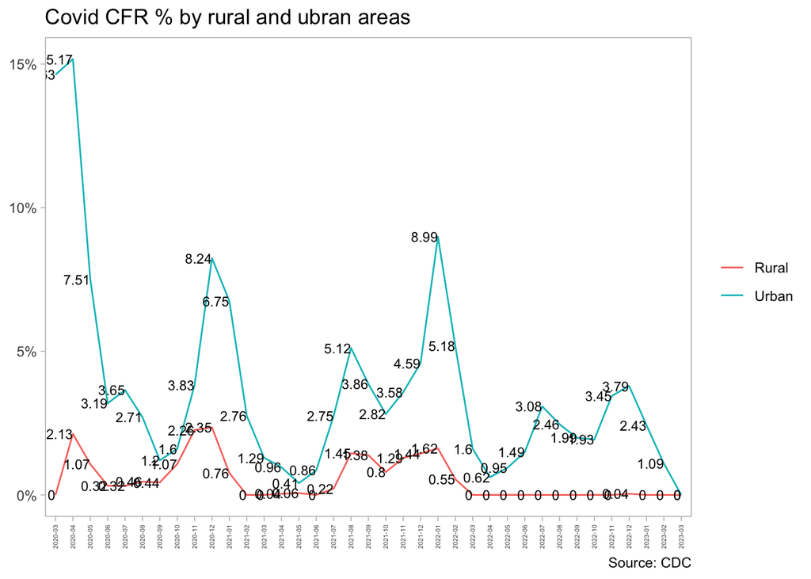

```r
# knitr::include_graphics(here::here("images", "cfr-rural-urban.png"), error = FALSE)

cdc_data %>%

  # Making sure we only count certain ICU admissions/non-admissions
  filter(icu_yn %in% c("Yes", "No")) %>%

  # Making sure we only count certain deaths/non-deaths
  filter(death_yn %in% c("Yes", "No")) %>%

  # Making sure we only count certain males/females
  filter(sex == "Male" | sex == "Female") %>%

  # Removing rows without age_group variable
  filter(age_group != "Missing") %>%

  # Renaming for clarity
  mutate(icu_yn = case_when(
    icu_yn == "Yes" ~ "ICU Admission",
    TRUE ~ "No ICU Admission"
  )) %>%

  # Wanted to change death_yn column to a binary numerical value, so I can use sum() in the summarise without needing to filter
  mutate(death_yn = case_when(
    death_yn == "Yes" ~ "1", # Note here that 1 = Death
    TRUE ~ "0"
  )) %>%

  # Now let's join the urban_rural table
  mutate(county_fips_code = as.double(county_fips_code)) %>%
  left_join(urban_rural, by = c("county_fips_code" = "fips_code")) %>%

  # And rename x2013_code names
  mutate(x2013_code = case_when(
    x2013_code == 1 ~ "Urban",
    x2013_code == 2 ~ "Urban",
    x2013_code == 3 ~ "Urban",
    x2013_code == 4 ~ "Rural",
    x2013_code == 5 ~ "Rural",
    x2013_code == 6 ~ "Rural"
  )) %>%

  # Grouping by the categories given in the example plot
  group_by(case_month, x2013_code) %>%

  # Calculating our inputs
  summarise(total_deaths = sum(as.numeric(death_yn)), total_cases = n()) %>%

  # Calculating our variable of interest
  mutate(cfr = total_deaths/total_cases) %>%

  # Collecting as data frame
  collect() %>%

  # Let's remove NAs
  filter(x2013_code != "NA") %>%
  filter(case_month != "2020-02") %>%

  # And plotting
  ggplot(aes(x = case_month, y = cfr)) +
  geom_line(aes(group = x2013_code, color = x2013_code)) +

  # Now aesthetics
  geom_text(aes(label = round(cfr*100,2), hjust = 1), color = "black",  size = 3) +
  labs(title = "Covid CFR % by rural and ubran areas", caption = "Source: CDC", x = NULL, y = NULL, color = NULL) +
  theme_light() +
  scale_y_continuous(labels = percent_format()) +
  theme(panel.grid = element_blank(),
        axis.text.x = element_text(angle = 90, vjust = 0.5, hjust = 1, size = 4))  +
  NULL
```

# 3 Money in US politics

```r
library(rvest)
library(robotstxt)
paths_allowed("https://www.opensecrets.org")
```

```
## [1] TRUE
```

```r
base_url <- "https://www.opensecrets.org/political-action-committees-pacs/foreign-connected-pacs/2022"

contributions_tables <- base_url %>%
  read_html()
```

```r
# Scraping the table for all of its information
contributions <- data.frame(

  contributions_tables %>%

  # Using inspect element to find the correct selector
  html_elements("#main > div.Main-wrap.l-padding.u-mt2 > div > div > div.l-primary > div:nth-child(1) > div > div:nth-child(5)") %>%
  html_table()
    ) %>%

  # Cleaning names of our data frame
  janitor::clean_names()



# Write a function to parse_currency
parse_currency <- function(x){
  x %>%

    # remove dollar signs
    str_remove("\\$") %>%

    # remove all occurrences of commas
    str_remove_all(",") %>%

    # convert to numeric
    as.numeric()
}



# Applying function to contributions

contributions <- contributions %>%

  # Using the function within a mutate of our existing data frame
  mutate(total = parse_currency(total),
         dems = parse_currency(dems),
         repubs = parse_currency(repubs))



# Clean country/parent co and contributions
contributions <- contributions %>%
  separate(country_of_origin_parent_company,
           into = c("country", "parent"),
           sep = "/",
           extra = "merge")

glimpse(contributions)
```

```
## Rows: 215
## Columns: 6
## $ pac_name_affiliate <chr> "Accenture (Accenture)", "Acreage Holdings", "Air L…
## $ country            <chr> "Ireland", "Canada", "France", "Netherlands", "UK",…
## $ parent             <chr> "Accenture plc", "Acreage Holdings", "L'Air Liquide…
## $ total              <dbl> 3000, 0, 17300, 193500, 186250, 84500, 31500, 2525,…
## $ dems               <dbl> 0, 0, 14800, 82500, 104000, 34500, 20500, 0, 218000…
## $ repubs             <dbl> 3000, 0, 2500, 111000, 82250, 50000, 11000, 2525, 2…
```

```r
# To create our function, with url as an input, we simply follow the same chain of commands as in the previous block
scrape_pac <- function(url) {

  # Process 1
  contributions_tables <- url %>%
    read_html()

  # Process 2
  contributions <- data.frame(

  contributions_tables %>%

  html_elements("#main > div.Main-wrap.l-padding.u-mt2 > div > div > div.l-primary > div:nth-child(1) > div > div:nth-child(5)") %>%
  html_table()
    ) %>%

  janitor::clean_names()

  # Process 3 & 4
  contributions <- contributions %>%
      separate(country_of_origin_parent_company,
           into = c("country", "parent"),
           sep = "/",
           extra = "merge") %>%

      mutate(total = parse_currency(total),
             dems = parse_currency(dems),
             repubs = parse_currency(repubs))

  contributions <- contributions %>%
    mutate(year = str_sub(url, -4))

  glimpse(contributions)

  }

# Defining urls for 2000, 2020 and 2022
url_2022 <- "https://www.opensecrets.org/political-action-committees-pacs/foreign-connected-pacs/2022"

url_2020 <-"https://www.opensecrets.org/political-action-committees-pacs/foreign-connected-pacs/2020"

url_2000 <-"https://www.opensecrets.org/political-action-committees-pacs/foreign-connected-pacs/2000"

# Creating a vector
os_urls <- c(url_2000, url_2020, url_2022)

# Running function over os_urls
contributions_all <- map_df(os_urls, scrape_pac)
```

```
## Rows: 150
## Columns: 7
## $ pac_name_affiliate <chr> "7-Eleven", "ABB Group", "Accenture", "ACE INA", "A…
## $ country            <chr> "Japan", "Switzerland", "UK", "UK", "Germany", "Ger…
## $ parent             <chr> "Ito-Yokado", "Asea Brown Boveri", "Accenture plc",…
## $ total              <dbl> 8500, 46000, 75984, 38500, 2000, 10500, 24000, 5825…
## $ dems               <dbl> 1500, 17000, 23000, 12500, 2000, 10000, 10000, 1050…
## $ repubs             <dbl> 7000, 28500, 52984, 26000, 0, 500, 14000, 47750, 15…
## $ year               <chr> "2000", "2000", "2000", "2000", "2000", "2000", "20…
## Rows: 225
## Columns: 7
## $ pac_name_affiliate <chr> "7-Eleven", "ABB Group (ABB Group)", "Accenture (Ac…
## $ country            <chr> "Japan", "Switzerland", "Ireland", "France", "Nethe…
## $ parent             <chr> "Seven & I Holdings", "Asea Brown Boveri", "Accentu…
## $ total              <dbl> 20000, 16900, 83500, 37800, 182000, 94750, 71300, 2…
## $ dems               <dbl> 1000, 6800, 50500, 15800, 79000, 30750, 36150, 0, 1…
## $ repubs             <dbl> 19000, 10100, 33000, 22000, 103000, 64000, 35150, 2…
## $ year               <chr> "2020", "2020", "2020", "2020", "2020", "2020", "20…
## Rows: 215
## Columns: 7
## $ pac_name_affiliate <chr> "Accenture (Accenture)", "Acreage Holdings", "Air L…
## $ country            <chr> "Ireland", "Canada", "France", "Netherlands", "UK",…
## $ parent             <chr> "Accenture plc", "Acreage Holdings", "L'Air Liquide…
## $ total              <dbl> 3000, 0, 17300, 193500, 186250, 84500, 31500, 2525,…
## $ dems               <dbl> 0, 0, 14800, 82500, 104000, 34500, 20500, 0, 218000…
## $ repubs             <dbl> 3000, 0, 2500, 111000, 82250, 50000, 11000, 2525, 2…
## $ year               <chr> "2022", "2022", "2022", "2022", "2022", "2022", "20…
```

```r
# Accuracy check
contributions_all %>%
  group_by(year) %>%
  count() # Looks good
```

```
## # A tibble: 3 × 2
## # Groups:   year [3]
##   year      n
##   <chr> <int>
## 1 2000    150
## 2 2020    225
## 3 2022    215
```

```r
write.csv(contributions_all, file.path("~/Library/CloudStorage/OneDrive-LondonBusinessSchool/Electives/E628 Data Science/dsb2023_mcheatle/data", "contributions-all.csv"))
```

# 4 Scraping consulting jobs

The website https://www.consultancy.uk/jobs/ lists job openings for consulting jobs.

```r
library(robotstxt)
paths_allowed("https://www.consultancy.uk") #is it ok to scrape?

base_url <- "https://www.consultancy.uk/jobs/page/1"

# First reading the html, so that we can use CSS selectors to retrieve attributes
listings_html <- base_url %>%
  read_html()

# Using the job selector to retrieve the job title
job <- listings_html %>%
html_nodes(css = "span.title") %>%
html_text2()

# Using the firm selector to retrieve the firm name
firm <- listings_html %>%
html_nodes(css = ".hide-phone .row-link") %>%
html_text2()

# Using the link selector, and concatenting the href on the end of the base url
link <- listings_html %>%
html_nodes(css = ".hide-phone .row-link") %>%
html_attr('href') %>%
str_c("https://www.consultancy.uk", .)

# Using the functional area to selector to retrieve the job area
functional_area <- listings_html %>%
html_elements(css = ".initial") %>%
html_text2()

# Using the type selector to retrieve the type of job
type <- listings_html %>%
html_nodes(css = ".hide-tablet-landscape .row-link") %>%
html_text2()

# Combining the above into a tibble
jobs_df <- tibble(job = job,
                    firm = firm,
                    functional_area = functional_area,
                    type = type,
                    link = link)
```

Identify the CSS selectors in order to extract the relevant information from this page, namely

1. job - span.title
2. firm - .hide-phone .row-link
3. functional area - .initial
4. type - .hide-tablet-landscape .row-link

```r
# To create our function, with url as an input, we simply follow the same chain of commands as in the previous block
scrape_jobs <- function(url) {

  listings_html <- url %>%
    read_html()

  job <- listings_html %>%
  html_nodes(css = "span.title") %>%
  html_text2()

  firm <- listings_html %>%
  html_nodes(css = ".hide-phone .row-link") %>%
  html_text2()

  link <- listings_html %>%
  html_nodes(css = ".hide-phone .row-link") %>%
  html_attr('href') %>%
  str_c("https://www.consultancy.uk", .)

  functional_area <- listings_html %>%
  html_elements(css = ".initial") %>%
  html_text2()

  type <- listings_html %>%
  html_nodes(css = ".hide-tablet-landscape .row-link") %>%
  html_text2()

  jobs_df <- tibble(job = job,
                    firm = firm,
                    functional_area = functional_area,
                    type = type,
                    link = link)

 # view(jobs_df) Only used this for checking

}

# Testing our function with page 2
scrape_jobs("https://www.consultancy.uk/jobs/page/2")

# Setting the base url, without a page number
base_url <- "https://www.consultancy.uk/jobs/page/"

# Setting url, as the base_url, concatenated with the numbers 1 to 8 (for all 8 pages of the website)
url <- str_c(base_url, 1:8)

all_consulting_jobs <- map_df(url, scrape_jobs)

write.csv(all_consulting_jobs, file.path("~/Library/CloudStorage/OneDrive-LondonBusinessSchool/Electives/E628 Data Science/dsb2023_mcheatle/data", "all_consulting_jobs.csv"))
```

Can you get all pages of ads, and not just the first one, `https://www.consultancy.uk/jobs/page/1` into a dataframe?

- Write a function called `scrape_jobs()` that scrapes information from the webpage for consulting positions. This function should
  - have one input: the URL of the webpage and should return a data frame with four columns (variables): job, firm, functional area, and type
  - Test your function works with other pages too, e.g., https://www.consultancy.uk/jobs/page/2. Does the function seem to do what you expected it to do?
  - Given that you have to scrape `...jobs/page/1`, `...jobs/page/2`, etc., define your URL so you can join multiple stings into one string, using `str_c()`. For instance, if `page` is 5, what do you expect the following code to produce?

```
base_url <- "https://www.consultancy.uk/jobs/page/1"
url <- str_c(base_url, page)
```

- Construct a vector called `pages` that contains the numbers for each page available
- Map the `scrape_jobs()` function over `pages` in a way that will result in a data frame called `all_consulting_jobs`.
- Write the data frame to a csv file called `all_consulting_jobs.csv` in the `data` folder.

# 5 Create a shiny app - OPTIONAL

We have already worked with the data on electricity production and usage, GDP/capita and CO2/capita since 1990. You have to create a simple Shiny app, where a user chooses a country from a drop down list and a time interval between 1990 and 2020 and shiny outputs the following

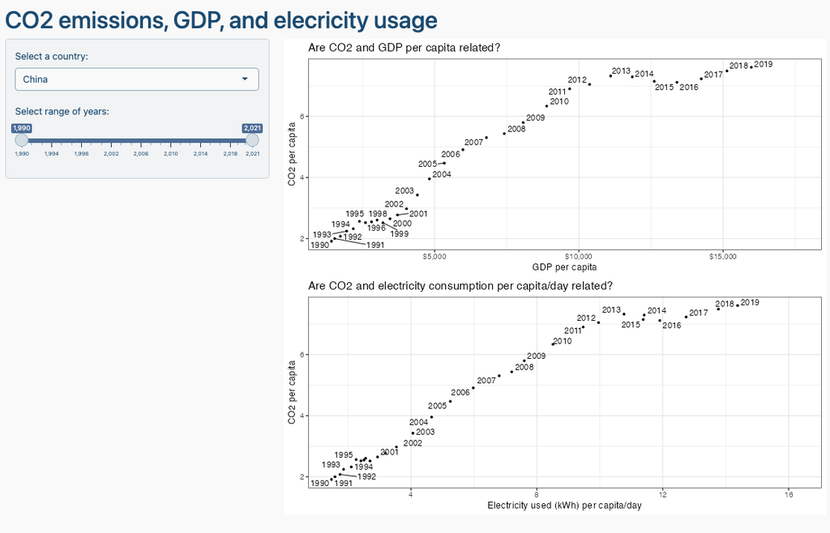

You can use chatGPT to get the basic layout of Shiny app, but you need to adjust the code it gives you. Ask chatGPT to create the Shiny app using the `gapminder` data and make up similar requests for the inputs/outpus you are thinking of deploying.

# 6 Details

- Who did you collaborate with: NA
- Approximately how much time did you spend on this problem set: 6h
- What, if anything, gave you the most trouble: Web scraping was really difficult to get started with, but once I got going it was fine